# EIR to PR

`mob_work`

David Smith

2023-01-31

RAMP $\uparrow$ `dev`|| `mob_work` | `pr2eir`

```r
purl("eir2pr.Rmd", output = "eir2pr.R", documentation = 0, quiet=TRUE)
```

## -

A set of wrappers to compute the *Pf*PR as a function of the *Pf*EIR for any model.

In both models, we use `Ztrace` to pass a values of $Z$ – the density of infective mosquitoes. We also set the parameters describing the overall blood feeding rate ($f$), and the human blood fraction ($q$). The daily EIR differs for every stratum:
$$\mbox{EIR} = \left(\beta
\cdot fqZ \right) \frac{H}{\sum H}$$
We choose values of $Z$ such that the annual EIR varies in a mesh from $0.1$ up to $1,000$.

## steady

Describe steady state relationships between *Pf*EIR and the *Pf*PR for a model.

### -

**Pseudocode**

- Set values of $Z$ in `Ztrace`
  - We set $Z$ but the EIR differs for every stratum. The population average EIR is
    $$\left(\beta \cdot fqZ \right) \frac{H}{\sum
    H}$$
  - We want to output values of the annual EIR in a mesh from $0.1$ up to $1,000$, so we must first find values of $Z$ such that aEIR $=0.1$ & $1,000$. We then take an even geometric mesh with `nZvals`
- For each value of $Z$, solve for the steady state of the system
- Compute and store the population average *Pf*PR and *Pf*EIR

**Output**

- `PfEIR` is returned in several forms:
  - a vector describing a range of values for the population average *Pf*EIR
  - a matrix describing the *Pf*EIR for each stratum
- *Pf*PR is returned in several forms:
  - `PfPR_pop` is the population average *Pf*PR
  - `PfPR_std` is the average *Pf*PR in children older than 2 but younger than 10 (for models defined ages)
  - `PfPR_u5` is the average *Pf*PR in children under 5 (for models defined ages)
  - `PfPR` is a matrix of steady state values for each stratum

**Inputs**

- `model` is a fully parameterized model
- `nZvals`

### code

```r
Z2eir = function(Z, model){
  model$MYZpar$Zm=Z
  H = F_H(0, 0, model)
  beta = F_beta(0, 0, model)
  eir = F_EIR(0, 0, model, beta)
  c(eir= sum(H*eir)/sum(H))
}
```

```r
eir2Z = function(eir, model){
  df = function(Z, model){
    (eir - Z2eir(Z, model))^2
  }
  optimize(df, c(0, 10000), model=model)$min
}
```

```r
eir2pr_Z = function(Z, model){
  model$MYZpar$Zm = Z
  y0 = get_inits(model)
  y = steady(y0, times = NULL, func=xDE_diffeqn_human, parms=model)$y
  H = F_H(0, 0, model)
  eir = Z2eir(Z, model)
  pfpr = y2pr_strata(y,model)
  c(aPfEIR=365*eir, PfPR=pfpr)
}
```

```r
eir2pr_steady = function(model, nZvals = 100){
  Zl = eir2Z(0.1/365, model)
  Zu = eir2Z(1000/365, model)
  Z = exp(seq(log(Zl), log(Zu), length.out = nZvals))
  t(sapply(Z, eir2pr_Z, model=model))
}
```

### demo

```r
ssTest0 = xde_setup_human("ssTest0", Xname = "SIS", HPop=100)

Xo = list(rho=0.3, eta=1/30, xi=2/365)

ssTest1 = xde_setup_human ("ssTest1", Xname = "SIP", Xopts = Xo, HPop = c(80, 20), searchB=c(.2,5), residence=c(1,1))

ssTest2 = xde_setup_human ("ssTest1", Xopts = Xo, Xname = "SIP")
```

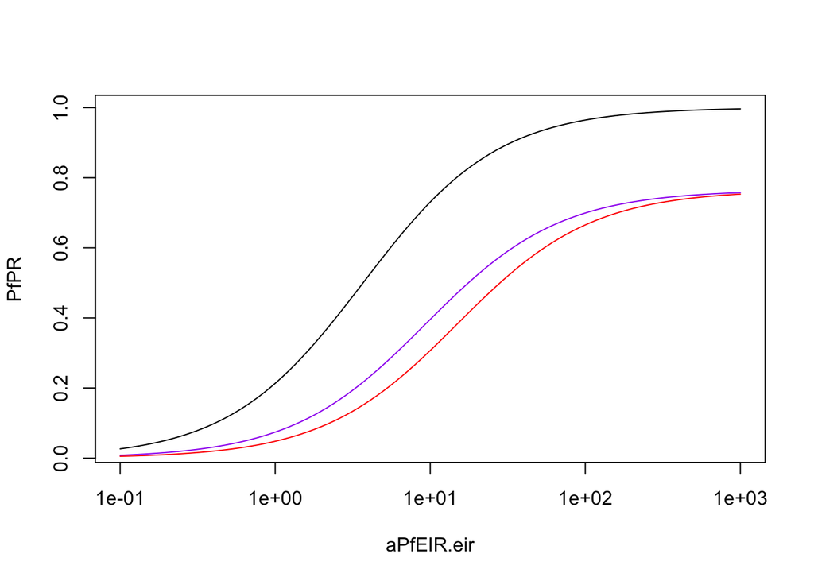

```r
ssTest1 = make_parameters_exposure_nb(ssTest1, sz=5)
ssTest2$Xpar$rho = .3
ssTest2$Xpar$eta = 1/30
ssTest2$Xpar$xi = 2/365
ssTest2 = make_parameters_exposure_nb(ssTest2, sz=5)

eirpr0 = eir2pr_steady(ssTest0)
eirpr1 = eir2pr_steady(ssTest1)
eirpr2 = eir2pr_steady(ssTest2)

plot(eirpr0, type = "l", log ="x")
lines(eirpr1, col = "red")
lines(eirpr2, col = "purple")
```

## orbit

Describe stable orbits and for the *Pf*EIR and the *Pf*PR for a model with a defined seasonal pattern, and output the seasonal *average* values in a form that is directly comparable with *steady state* relationships.

### -

**Pseudocode**

- We define a mesh on $Z$ as we did for `eir2pr_steady`
- For each value of $Z$, we find the stable orbit.
- Compute and store the orbits and the population average *Pf*PR and *Pf*EIR

**Output**

- `PfEIR` is returned in several forms:
  - a vector describing a range of values for the annual average *Pf*EIR averaged across the population
  - a vector describing a range of values for the population average *Pf*EIR across the year
  - a matrix describing the *Pf*EIR for each stratum
- *Pf*PR is returned in several forms:
  - `PfPR_pop` is the population average *Pf*PR
  - `PfPR_std` is the average *Pf*PR in children older than 2 but younger than 10 (for models defined ages)
  - `PfPR_u5` is the average *Pf*PR in children under 5 (for models defined ages)
  - `PfPR` is a matrix of steady state values for each stratum

**Inputs**

- `model` is a fully parameterized model
- `nZvals`

### code

```r
reset_inits_X = function(model, y){
  UseMethod("reset_inits_X", model$Xpar)
}

reset_inits_X.SIS = function(model, y){
  model$Xinits$X0 = y[model$Xpar$X_ix]
  return(model)
}

reset_inits_X.SIP = function(model, y){
  model$Xinits$X0 = y[model$Xpar$X_ix]
  model$Xinits$P0 = y[model$Xpar$P_ix]
  return(model)
}
```

```r
Z2eir_season = function(Z, tt, model){
  tt = tt[-1]
  model$MYZpar$Zm=Z
  H = F_H(tt, 0, model)
  beta = F_beta(tt, 0, model)
  eir = sapply(tt, F_EIR, y=0, pars=model, beta=beta)
  c(eir=sum(H*eir)/sum(H)/length(tt))
}
```

```r
eir2Z_season = function(eir, tt, model){
  dfs = function(Z, tt, model, eir){
    (eir - Z2eir_season(Z, tt, model))^2
  }
  optimize(dfs, c(0, 10000), tt=tt, model=model, eir=eir)$min
}
```

```r
eir2pr_Z_season = function(Z, model, nT){
  tt = seq(0,365, length.out = nT+1)
  model$MYZpar$Zm = Z
  y0 = get_inits(model)
  ode(y0, times = seq(0,7300, by = 10), func=xDE_diffeqn_human, parms=model) -> out
  y0 = tail(out, 1)[-1]
  model = reset_inits_X(model, y0)

  X = ode(y0, times = tt, func=xDE_diffeqn_human, parms=model)
  H = F_H(0, 0, model)
  Zs = F_Z(tt, 0, model)
  eirs = sapply(Zs, Z2eir, model=model)
  pfpr = orbits2pr_strata(X,model)
  c(aPfEIR=365*eirs, PfPR=pfpr)
}
```

```r
eir2pr_season = function(model, nT = 24, nZvals = 100){
  tt = seq(0, 365, length.out = nT+1)
  Zl = eir2Z_season(0.1/365, tt, model)
  Zu = eir2Z_season(1000/365, tt, model)
  Z = exp(seq(log(Zl), log(Zu), length.out = nZvals))
  t(sapply(Z, eir2pr_Z_season, model=model, nT=nT))-> out
  aPfEIR = out[,1:(nT+1)]
  mean_eir = apply(aPfEIR, 1, mean)
  PfPR = out[,nT+1 + 1:(nT+1)]
  mean_pr = apply(PfPR, 1, mean)
  list(aPfEIR = aPfEIR, PfPR=PfPR, mean_pr=mean_pr, mean_eir=mean_eir)
}
```

### demo

#### orbits

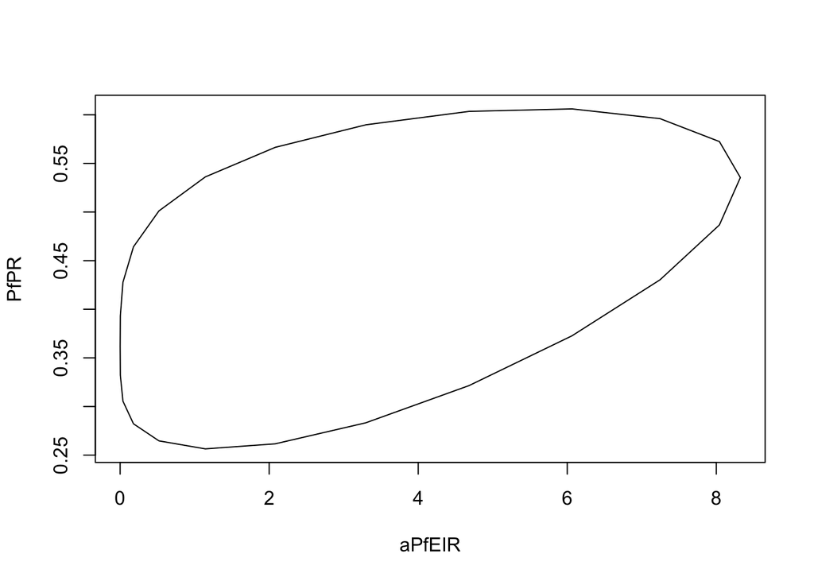

#### scaling

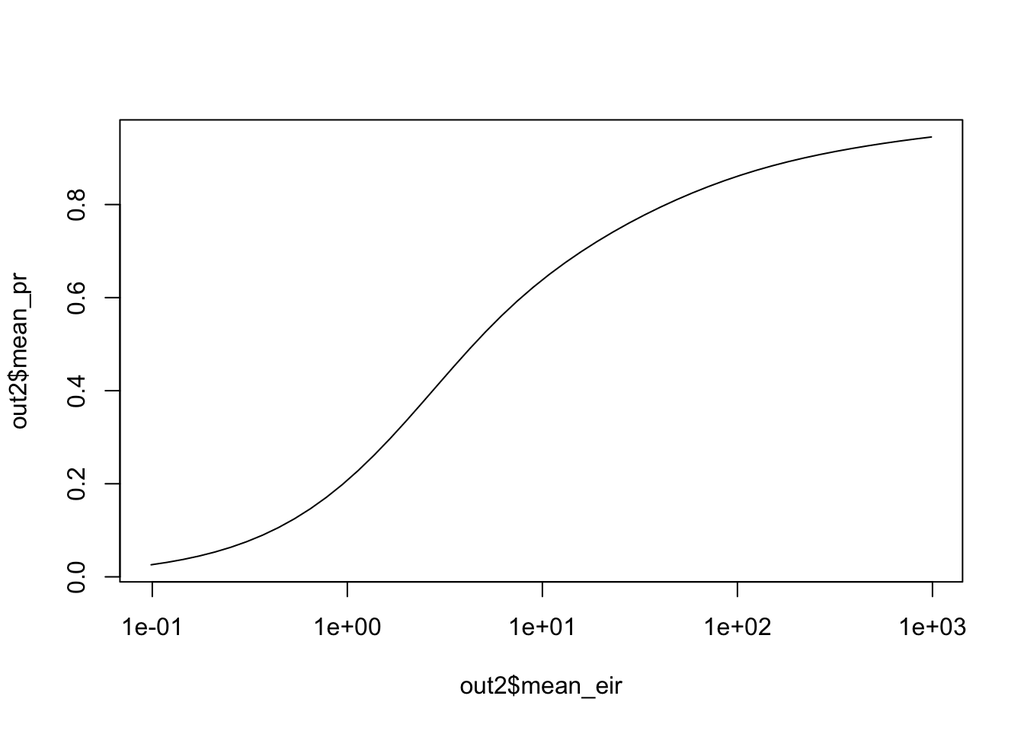

```r
eir2pr_season(ssTest0, nT=24, nZvals = 50) -> out2
plot(out2$mean_eir, out2$mean_pr, type = "l", log = "x")
```

#### combined

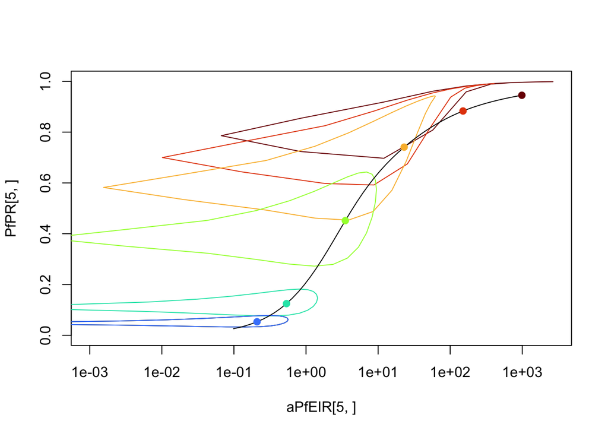